# Simulation-Based Power Analysis

Part 4: By-participant adjustments to the slope — Handout

Author

Affiliation

Filip Andras, David López-García & David Sánchez Casasola

Centro de Investigación Mente Cerebro y Comportamiento (CIMCYC), Universidad de Granada

Published

26 May 2026

# 1 From varying intercepts to varying slopes

So far our simulations have allowed each subject to have **their own intercept** (their mean processing speed), but the lexical-frequency effect was a constant 50 ms for everyone.

That assumption is unrealistic. In real experiments, some subjects show a larger frequency effect than others. Some show a smaller effect. Some are close to the group mean.

This part of the course **adds by-subject variability to the slope** as well. The generative process gains one parameter ($\sigma_{u1}$) and one new term in the formula.

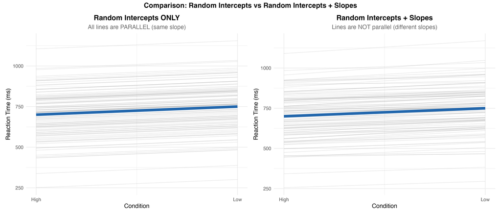

Figure 1: Visual contrast of the two models. **Left:** random intercepts only — every line has a different baseline but the same slope, so the lines are parallel. **Right:** random intercepts AND random slopes — the lines fan out, reflecting that subjects also differ in the *size* of their frequency effect.

The left panel is the model from Part 2/3. The right panel is what we are about to build in Part 4. Notice the lines are no longer parallel — that fanning is the visual signature of by-subject slope variability.

# 2 Generating subject-specific slopes

We model subjects’ variation around the mean slope as draws from a normal distribution centred on zero, with some standard deviation. A reasonable starting value is $\sigma_{u1} = 20$ ms:

$$u_{1i} \sim \text{Normal}(0, 20)$$

In code:

```r
(u1 <- round(rnorm(n, mean = 0, sd = 20)))
```

```
 [1]  27 -11   7  13   8  -2  30  -2  40  -1  26  46 -28  -6  -3  13  -6 -53 -49  26
```

Some subjects have positive $u_{1i}$ (a larger-than-average effect), others negative (a smaller-than-average effect). Adding the adjustments to the mean slope of 50 ms gives each subject’s own effect size:

```r
(50 + u1)
```

```
 [1] 77 39 57 63 58 48 80 48 90 49 76 96 22 44 47 63 44 -3  1 76
```

So some subjects will show ~30 ms, others ~70 ms, around the population mean of 50 ms.

# 3 Generating the data

The full generative formula now becomes:

$$rt_{ij} = \beta_0 + u_{0i} + (\beta_1 + u_{1i}) \times \text{cond.cod}_{ij} + \varepsilon_{ij}$$

with:

- $u_{0i} \sim \text{Normal}(0, 150)$ — by-subject adjustments to the intercept
- $u_{1i} \sim \text{Normal}(0, 20)$ — by-subject adjustments to the slope
- $\varepsilon_{ij} \sim \text{Normal}(0, 200)$ — residual error

This is the **varying intercepts and varying slopes** model.

Translated to code, with the nested `rep()` calls from Part 3:

```r
rt <- 725 +
        rep(rep(round(rnorm(n, 0, 150)), each = k), times = 2) +   # by-subject intercepts
        (50 +
          rep(rep(round(rnorm(n, 0,  20)), each = k), times = 2)) * cond.cod +  # by-subject slopes
        rnorm(n * k * 2, 0, 200)                                   # residual error

sim_dat$rt <- rt
```

# 4 Visualising by-subject slopes

Plotting each subject’s data with a per-subject regression line shows the variability in slopes:

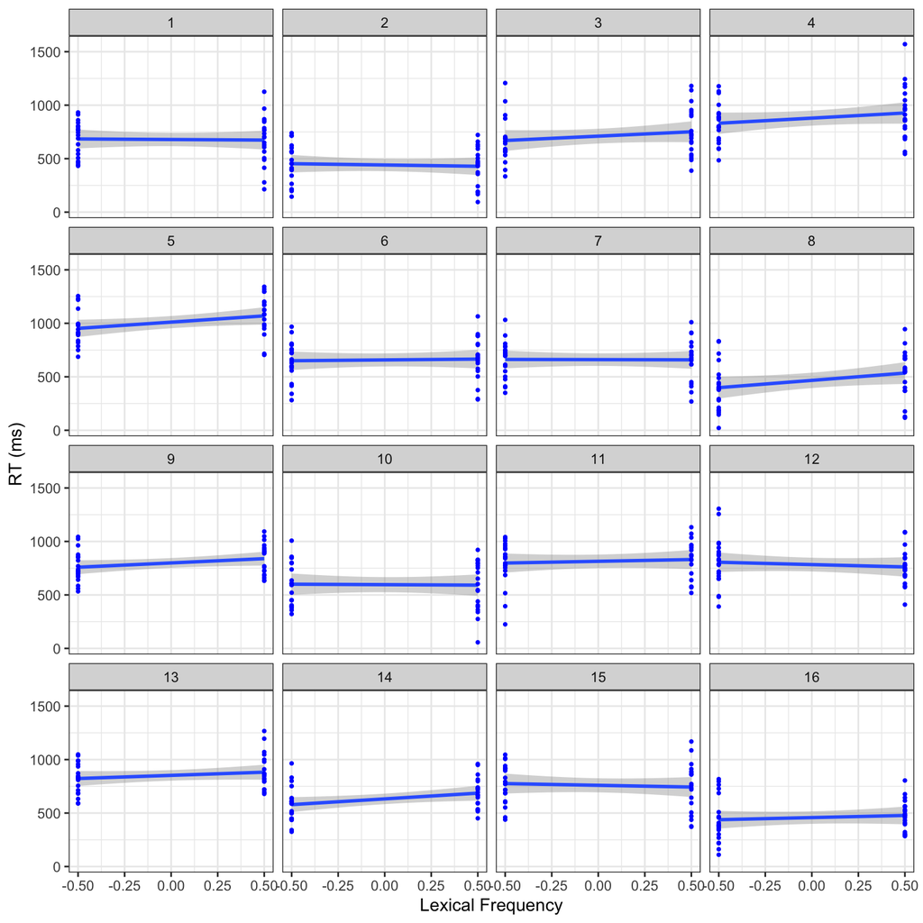

Figure 2: Per-subject regression lines for the first 16 subjects. Different slopes mean different sizes of the lexical-frequency effect.

Each panel is one subject. The slope of the blue line is that subject’s lexical-frequency effect. They are clearly different across people — that is exactly the variability we just added to the data-generating process.

# 5 Fitting the uncorrelated random-slopes model

The corresponding LMM allows both intercepts and slopes to vary by subject. We use the **double vertical bar** `||` syntax to fit a model that does *not* estimate the correlation between intercepts and slopes:

```r
m3 <- lmer(rt ~ cond.cod + (1 + cond.cod || subj), sim_dat,
           control = lmerControl(calc.derivs = FALSE))
summary(m3)
```

```
Linear mixed model fit by REML. t-tests use Satterthwaite's method ['lmerModLmerTest']
Formula: rt ~ cond.cod + (1 + cond.cod || subj)
   Data: sim_dat
Control: lmerControl(calc.derivs = FALSE)

REML criterion at convergence: 10748.4

Scaled residuals:
    Min      1Q  Median      3Q     Max
-2.9403 -0.6618  0.0034  0.6994  3.4952

Random effects:
 Groups   Name        Variance Std.Dev.
 subj     (Intercept) 27638.9  166.25
 subj.1   cond.cod      882.7   29.71
 Residual             37413.6  193.43
Number of obs: 800, groups:  subj, 20

Fixed effects:
            Estimate Std. Error     df t value          Pr(>|t|)
(Intercept)   672.54      37.80  19.00  17.793 0.000000000000264 ***
cond.cod       31.74      15.21  19.00   2.087            0.0506 .
---
Signif. codes:  0 '***' 0.001 '**' 0.01 '*' 0.05 '.' 0.1 ' ' 1

Correlation of Fixed Effects:
         (Intr)
cond.cod 0.000
```

**Note**

The `||` (double bar) syntax fits **uncorrelated** random effects. The single bar `|` would fit the **correlated** version — but in Part 3 we saw that correlated random effects need additional structure in the generative process to avoid the $\pm 1$ collapse.

Part 5 will add a true correlation between intercepts and slopes and switch back to the `|` syntax.

# 6 A more sophisticated generative process

Instead of generating subject adjustments inline with nested `rep()` calls, we can build a **separate data frame** with one row per subject containing both random effects. This generalises cleanly when we later add more random effects.

```r
n <- 20  # subjects
k <- 20  # trials per condition

cond.cod <- rep(c(-0.5, 0.5), each = n * k)
sim_dat  <- data.frame(
  subj     = rep(rep(1:n, each = k), times = 2),
  cond.cod = cond.cod
)

sigma_u0 <- 150
sigma_u1 <- 20

u <- data.frame(
  subject = 1:n,
  u0      = rnorm(n, 0, sigma_u0), # random intercepts
  u1      = rnorm(n, 0, sigma_u1)  # random slopes
)
head(u)
```

```
  subject         u0        u1
1       1  32.932202 -18.00184
2       2  55.544163  34.46666
3       3  41.866259  38.18084
4       4  30.291366 -15.54282
5       5  -1.949481 -26.04611
6       6 -13.629751  52.46990
```

Now `u` is a small data frame with one row per subject. We will plug it into the data-generating formula by looking up each subject’s adjustments as we go through the rows of `sim_dat`.

# 7 Generating RTs row by row

The row-by-row loop reads cleanly because each row’s adjustment comes from the corresponding row of `u`:

```r
nrows <- dim(sim_dat)[1]
rt    <- rep(NA, nrows)

b0    <- 725
b1    <- 50
sigma <- 200

for (i in 1:nrows) {
  rt[i] <- b0 +                                                  # grand mean
           u[sim_dat[i, ]$subj, ]$u0 +                           # subject intercept
           (b1 + u[sim_dat[i, ]$subj, ]$u1) * sim_dat[i, ]$cond.cod +  # subject slope
           rnorm(1, 0, sigma)                                    # residual error
}

sim_dat$rt <- rt
```

The expression `u[sim_dat[i, ]$subj, ]$u0` is the key lookup. It says:

- `sim_dat[i, ]$subj` is the subject id for the $i$-th row of `sim_dat`.
- `u[..., ]` selects the row of `u` for that subject.
- `$u0` extracts the intercept adjustment from that row.

To see this concretely, here is what happens for `i = 1`:

```r
i <- 1

# subject id of the first row in sim_dat:
sim_dat[i, ]$subj
```

```
[1] 1
```

```r
# intercept adjustment for that subject:
u[sim_dat[i, ]$subj, ]$u0
```

```
[1] 32.9322
```

```r
# slope adjustment for that subject:
u[sim_dat[i, ]$subj, ]$u1
```

```
[1] -18.00184
```

```r
# verify the values match the first rows of u:
head(u)
```

```
  subject         u0        u1
1       1  32.932202 -18.00184
2       2  55.544163  34.46666
3       3  41.866259  38.18084
4       4  30.291366 -15.54282
5       5  -1.949481 -26.04611
6       6 -13.629751  52.46990
```

# 8 Sanity check: fit the model

Fit the same uncorrelated random-slopes model to the newly generated data and check that the parameter estimates approximately match the values we used to generate the data:

```r
m3_check <- lmer(rt ~ cond.cod + (1 + cond.cod || subj), sim_dat,
                 control = lmerControl(calc.derivs = FALSE))
summary(m3_check)
```

```
Linear mixed model fit by REML. t-tests use Satterthwaite's method ['lmerModLmerTest']
Formula: rt ~ cond.cod + (1 + cond.cod || subj)
   Data: sim_dat
Control: lmerControl(calc.derivs = FALSE)

REML criterion at convergence: 10810

Scaled residuals:
    Min      1Q  Median      3Q     Max
-3.2049 -0.6476  0.0023  0.6795  3.4521

Random effects:
 Groups   Name        Variance Std.Dev.
 subj     (Intercept) 10356.9  101.77
 subj.1   cond.cod      388.4   19.71
 Residual             41534.4  203.80
Number of obs: 800, groups:  subj, 20

Fixed effects:
            Estimate Std. Error     df t value             Pr(>|t|)
(Intercept)   753.63      23.87  19.00  31.573 < 0.0000000000000002 ***
cond.cod       61.40      15.07  19.00   4.074             0.000647 ***
---
Signif. codes:  0 '***' 0.001 '**' 0.01 '*' 0.05 '.' 0.1 ' ' 1

Correlation of Fixed Effects:
         (Intr)
cond.cod 0.000
```

The fixed-effect estimates should be close to 725 (intercept) and 50 (slope), and the random-effect SDs should be close to 150 (intercept) and 20 (slope).

# 9 Wrapping it in a function

We will reuse this design many times, so we wrap the row-by-row loop in a generic function `gendat_ldt()`:

```r
gendat_ldt <- function(n        = 20,    # subjects
                       k        = 20,    # trials per condition per subject
                       b0       = 725,   # grand mean RT
                       b1       = 50,    # frequency effect
                       sigma_u0 = 150,   # SD of subject random intercepts
                       sigma_u1 = 20,    # SD of subject random slopes
                       sigma    = 200) { # residual SD

  u <- data.frame(subject = 1:n,
                  u0      = rnorm(n, 0, sigma_u0),
                  u1      = rnorm(n, 0, sigma_u1))

  cond.cod <- rep(c(-0.5, 0.5), each = n * k)
  subj     <- rep(rep(1:n, each = k), times = 2)
  sim_dat  <- data.frame(subj = subj, cond.cod = cond.cod)

  nrows <- dim(sim_dat)[1]
  rt    <- rep(NA, nrows)

  for (i in 1:nrows) {
    rt[i] <- b0 +
             u[sim_dat[i, ]$subj, ]$u0 +
             (b1 + u[sim_dat[i, ]$subj, ]$u1) * sim_dat[i, ]$cond.cod +
             rnorm(1, 0, sigma)
  }

  sim_dat$rt <- rt
  sim_dat
}
```

Quick test:

```r
sim_dat <- gendat_ldt(n = 20, k = 20, b0 = 725, b1 = 50,
                      sigma_u0 = 100, sigma_u1 = 20, sigma = 200)

m <- lmer(rt ~ cond.cod + (1 + cond.cod || subj), sim_dat,
          control = lmerControl(calc.derivs = FALSE))
summary(m)
```

```
Linear mixed model fit by REML. t-tests use Satterthwaite's method ['lmerModLmerTest']
Formula: rt ~ cond.cod + (1 + cond.cod || subj)
   Data: sim_dat
Control: lmerControl(calc.derivs = FALSE)

REML criterion at convergence: 10766.6

Scaled residuals:
    Min      1Q  Median      3Q     Max
-3.0177 -0.6556 -0.0036  0.6989  3.3371

Random effects:
 Groups   Name        Variance Std.Dev.
 subj     (Intercept) 12640.9  112.43
 subj.1   cond.cod      181.2   13.46
 Residual             39154.5  197.87
Number of obs: 800, groups:  subj, 20

Fixed effects:
            Estimate Std. Error     df t value             Pr(>|t|)
(Intercept)   741.72      26.10  19.00   28.42 < 0.0000000000000002 ***
cond.cod       64.83      14.31  18.99    4.53             0.000229 ***
---
Signif. codes:  0 '***' 0.001 '**' 0.01 '*' 0.05 '.' 0.1 ' ' 1

Correlation of Fixed Effects:
         (Intr)
cond.cod 0.000
```

# 10 Power estimation

Now that the function generates data cleanly, the power loop is a one-liner per iteration. We use $|t| > 2$ as a quick approximation for $p < 0.05$:

```r
nsim  <- 1000
tvals <- rep(NA, nsim)

for (i in 1:nsim) {
  sim_dat <- gendat_ldt(n = 20, k = 20, b0 = 725, b1 = 50,
                        sigma_u0 = 150, sigma_u1 = 20, sigma = 200)

  m <- lmer(rt ~ cond.cod + (1 + cond.cod || subj), sim_dat,
            control = lmerControl(calc.derivs = FALSE))
  tvals[i] <- summary(m)$coefficients[2, 4]
}

power_estimate <- mean(abs(tvals) > 2)
round(power_estimate, 3)
```

```
[1] 0.909
```

# 11 Parameter recovery

With five parameters to recover ($\beta_0$, $\beta_1$, $\sigma_{u0}$, $\sigma_{u1}$, $\sigma$), we check that the model can return all of them under repeated sampling. For this run we increase the number of trials to `k = 40` and the slope SD to `sigma_u1 = 30` so the slope variance is easier to estimate:

```r
nsim   <- 1000
params <- matrix(rep(NA, nsim * 5), ncol = 5)

for (i in 1:nsim) {
  sim_dat <- gendat_ldt(n = 20, k = 40, b0 = 725, b1 = 50,
                        sigma_u0 = 150, sigma_u1 = 30, sigma = 200)
  m <- lmer(rt ~ cond.cod + (1 + cond.cod || subj), sim_dat,
            control = lmerControl(calc.derivs = FALSE))

  params[i, 1] <- summary(m)$coefficients[1, 1]  # intercept
  params[i, 2] <- summary(m)$coefficients[2, 1]  # slope
  params[i, 3] <- attr(VarCorr(m), "sc")         # SD residuals
  vc <- as.data.frame(VarCorr(m))
  params[i, 4] <- vc$sdcor[1]                    # SD random intercepts
  params[i, 5] <- vc$sdcor[2]                    # SD random slopes
}
```

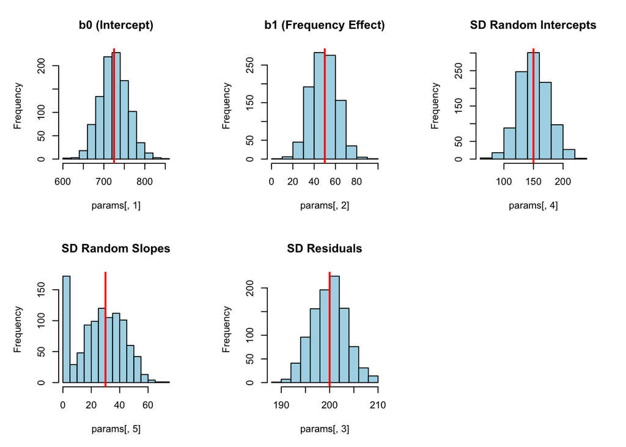

Figure 3: Parameter recovery for the varying-slopes model with n = 20, k = 40, 1000 simulations. Red lines mark the true generating values.

All five histograms are centred near the true generating values. The varying- slopes model can recover its parameters under this design, although the slope variance ($\sigma_{u1}$) is the noisiest — variance components are harder to estimate than fixed effects.

# 12 Summary and next step

In this part we:

- Added **by-subject slope variability** to the data-generating process via a new parameter $\sigma_{u1}$.
- Built a clean row-by-row data generator using a separate data frame `u` of subject random effects.
- Wrapped the generator in a reusable function `gendat_ldt()`.
- Estimated power and verified parameter recovery for the varying-intercepts-and-slopes model.

So far the by-subject intercepts and slopes are drawn from **independent** distributions. In the next part we relax this assumption: subjects whose overall RT is faster might also show a smaller frequency effect, which would create a **correlation** between intercepts and slopes.